# Lab-03-PECK

April Peck

11/1/2021

```r
# load function source files
# note: all of these are R objects that will be used throughout this .rmd file
import::here("build_year",
             "RELEVANT_FILES",
             "obtain_crosswalk",
             "create_final_metadata_file",
             "compare_dfs",
             "jplot",
             # notice the use of here::here() that points to the .R file
             # where all these R objects are created
             .from = here::here("analysis/utilities.R"),
             .character_only = TRUE)
```

```
## [1] "Starting on 1970"
## [1] "Finished! Moving onto the next decade."
## [1] "Starting on 1980"
## [1] "Finished! Moving onto the next decade."
## [1] "Starting on 1990"
## [1] "Finished! Moving onto the next decade."
## [1] "Starting on 2000"
## [1] "Finished! Moving onto the next decade."
## [1] "Starting on 2010"
## [1] "Finished! No more data to parse."
```

```r
#this works when I knit, but I get an error when I use it for just running the code.

#import::here("../../analysis/utilities.R")
# this works when I run the code, but not when I knit.
```

# Data

Load data

```r
d1 <- readRDS( here::here( "data/rodeo/LTDB-1990.rds" ) )
d2 <- readRDS( here::here( "data/rodeo/LTDB-2000.rds" ) )
md <- readRDS( here::here( "data/rodeo/LTDB-META-DATA.rds" ) )

# check to make sure we are not losing
# or gaining observations in the merge
nrow( d1 )
```

```
## [1] 72693
```

```r
d1 <- select( d1, - year )
d2 <- select( d2, - year )

d <- merge( d1, d2, by="tractid" )
d <- merge( d, md, by="tractid" )

nrow( d )
```

```
## [1] 72693
```

### Filter rural districts

```r
table( d$urban )
```

```
##
## rural urban
## 12971 59722
```

```r
d <- filter( d, urban == "urban" )
```

### Identify Common Variables

I have created a function to compare variables from two datasets:

```r
vars <- compare_dfs( df1=d1, df2=d2 )
```

```
## [1] "SHARED VARIABLES:"
##   [1] "a15asn"  "a15blk"  "a15hsp"  "a15ntv"  "a15wht"  "a18und"  "a60asn"
##   [8] "a60blk"  "a60hsp"  "a60ntv"  "a60up"   "a60wht"  "a75up"   "ag15up"
##  [15] "ag25up"  "ag5up"   "ageasn"  "ageblk"  "agehsp"  "agentv"  "agewht"
##  [22] "asian"   "china"   "clf"     "cni16u"  "col"     "cuban"   "dapov"
##  [29] "dbpov"   "dflabf"  "dfmpov"  "dhpov"   "dis"     "dmulti"  "dnapov"
##  [36] "dpov"    "dwpov"   "empclf"  "family"  "fb"      "fhh"     "filip"
##  [43] "flabf"   "geanc"   "gefb"    "h10yrs"  "h30old"  "haw"     "hh"
##  [50] "hha"     "hhb"     "hhh"     "hhw"     "hinc"    "hinca"   "hincb"
##  [57] "hinch"   "hincw"   "hisp"    "hs"      "hu"      "incpc"   "india"
##  [64] "iranc"   "irfb"    "itanc"   "itfb"    "japan"   "korea"   "lep"
##  [71] "manuf"   "mar"     "mex"     "mhmval"  "mrent"   "multi"   "n10imm"
##  [78] "n65pov"  "napov"   "nat"     "nbpov"   "nfmpov"  "nhblk"   "nhpov"
##  [85] "nhwht"   "nnapov"  "npov"    "ntv"     "nwpov"   "ohu"     "olang"
##  [92] "own"     "pop"     "pr"      "prof"    "rent"    "ruanc"   "rufb"
##  [99] "scanc"   "scfb"    "semp"    "tractid" "unemp"   "vac"     "vet"
## [106] "viet"    "wds"
## [1] "NOT SHARED:"
## [1] "ag16cv"  "ag18cv"  "hu00sp"  "hu90sp"  "ohu00sp" "ohu90sp" "pop90.1"
```

### Create Dataset for Analysis

Create subset for the analysis

```r
d.full <- d  # keep a copy so don't have to reload
d <- d.full  # story original in case you need to reset anything

d <- select( d, tractid, mhmval90, mhmval00, hinc90,
             hu90, own90, rent90,
             empclf90, clf90, unemp90, prof90,
             dpov90, npov90,
             ag25up90, hs90, col90,
             pop90.x, nhwht90, nhblk90, hisp90, asian90,
             cbsa, cbsaname )
d <-
  d %>%
  mutate( p.white = 100 * nhwht90 / pop90.x,
          p.black = 100 * nhblk90 / pop90.x,
          p.hisp = 100 * hisp90 / pop90.x,
          p.asian = 100 * asian90 / pop90.x,
          p.hs = 100 * (hs90+col90) / ag25up90,
          p.col = 100 * col90 / ag25up90,
          p.prof = 100 * prof90 / empclf90,
          p.unemp = 100 * unemp90 / clf90,
          pov.rate = 100 * npov90 / dpov90 )
```

If you call the stargazer() function with a linear model object (a regression model) it will create a nicely-formatted regression table for you.

If you instead use a data frame object it will create a table of descriptive statistics.

You can set the statistics you would like reported in the table with the summary.stat= argument.

```r
stargazer( d,
           type=s.type,
           digits=0,
           summary.stat = c("min", "p25","median","mean","p75","max") )
```

| Statistic | Min | Pctl(25) | Median | Mean | Pctl(75) | Max |
| --- | --- | --- | --- | --- | --- | --- |
| mhmval90 | 0 | 58,800 | 86,500 | 112,399 | 141,800 | 500,001 |
| mhmval00 | 0 | 81,600 | 119,900 | 144,738 | 173,894 | 1,000,001 |
| hinc90 | 4,999 | 24,355 | 32,033 | 34,160 | 41,520 | 150,001 |
| hu90 | 0 | 916 | 1,337 | 1,382 | 1,804 | 11,003 |
| own90 | 0 | 422 | 744 | 788 | 1,093 | 8,180 |
| rent90 | 0 | 168 | 358 | 476 | 663 | 8,653 |
| empclf90 | 0 | 1,015 | 1,555 | 1,625 | 2,157 | 11,816 |
| clf90 | 0 | 1,101 | 1,664 | 1,732 | 2,291 | 12,497 |
| unemp90 | 0 | 49 | 88 | 107 | 143 | 1,165 |
| prof90 | 0 | 192 | 359 | 451 | 616 | 6,290 |
| dpov90 | 0 | 2,219 | 3,250 | 3,332 | 4,365 | 23,619 |
| npov90 | 0 | 112 | 248 | 406 | 526 | 5,890 |
| ag25up90 | 0 | 1,444 | 2,121 | 2,187 | 2,865 | 18,461 |
| hs90 | 0 | 626 | 1,064 | 1,141 | 1,559 | 12,383 |
| col90 | 0 | 162 | 335 | 483 | 652 | 8,575 |
| pop90.x | 0 | 2,283 | 3,325 | 3,419 | 4,464 | 35,721 |
| nhwht90 | 0 | 1,262 | 2,424 | 2,513 | 3,575 | 21,561 |
| nhblk90 | 0 | 18 | 76 | 426 | 331 | 12,121 |
| hisp90 | 0 | 27 | 75 | 347 | 280 | 13,873 |
| asian90 | 0 | 9 | 31 | 111 | 94 | 7,899 |
| p.white | 0 | 64 | 87 | 74 | 95 | 100 |
| p.black | 0 | 1 | 3 | 12 | 10 | 100 |
| p.hisp | 0 | 1 | 3 | 10 | 9 | 100 |
| p.asian | 0 | 0 | 1 | 3 | 3 | 94 |
| p.hs | 0 | 69 | 74 | 74 | 80 | 100 |
| p.col | 0 | 10 | 18 | 22 | 30 | 100 |
| p.prof | 0 | 17 | 25 | 27 | 34 | 100 |
| p.unemp | 0 | 4 | 5 | 7 | 8 | 64 |
| pov.rate | 0 | 4 | 8 | 12 | 16 | 100 |

# Part 01 - Change in Home Values

Initial conditions in 1990:

*(Note: inflation calculation based on calculator at westegg.com)*

```r
# adjust 1990 home values for inflation
mhv.90 <- d$mhmval90 * 1.333
mhv.00 <- d$mhmval00

mhv.change <- mhv.00 - mhv.90

df <- data.frame( MedianHomeValue1990=mhv.90,
                  MedianHomeValue2000=mhv.00,
                  Change.90.to.00=mhv.change )

stargazer( df,
           type=s.type,
           digits=0,
           summary.stat = c("min", "p25","median","mean","p75","max") )
```

| Statistic | Min | Pctl(25) | Median | Mean | Pctl(75) | Max |
| --- | --- | --- | --- | --- | --- | --- |
| MedianHomeValue1990 | 0 | 78,380 | 115,304 | 149,828 | 189,019 | 666,501 |
| MedianHomeValue2000 | 0 | 81,600 | 119,900 | 144,738 | 173,894 | 1,000,001 |
| Change.90.to.00 | -666,501 | -24,948 | -468 | -5,090 | 18,080 | 1,000,001 |

### Histogram of MHV

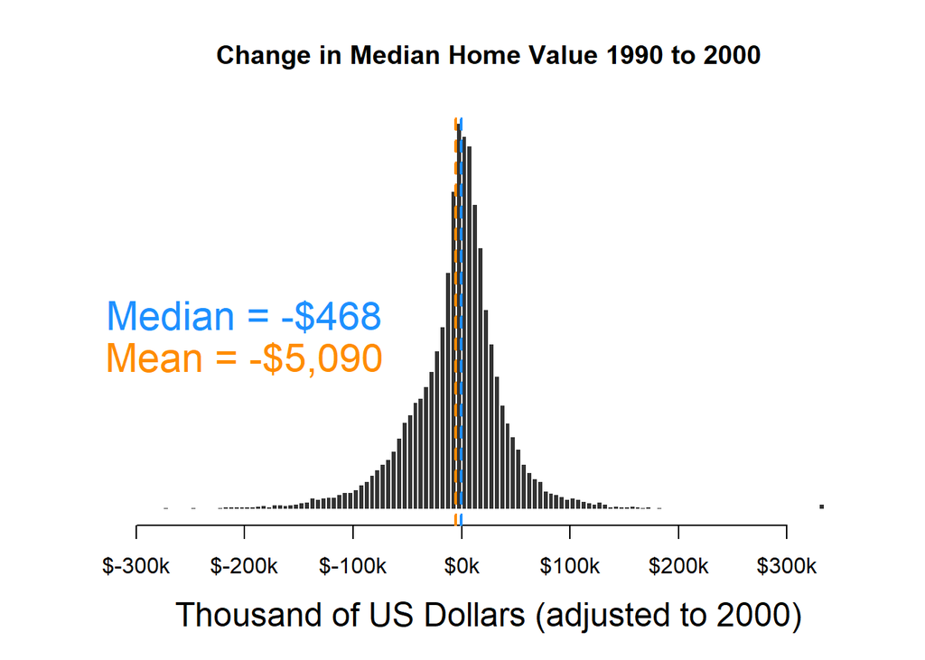

```r
hist( mhv.change/1000, breaks=500,
      xlim=c(-300,350), yaxt="n", xaxt="n",
      xlab="Thousand of US Dollars (adjusted to 2000)", cex.lab=1.5,
      ylab="", main="Change in Median Home Value 1990 to 2000",
      col="gray20", border="white" )

axis( side=1, at=seq( from=-300, to=350, by=100 ),
      labels=paste0( "$", seq( from=-300, to=350, by=100 ), "k" ) )

mean.x <- mean( mhv.change/1000, na.rm=T )
abline( v=mean.x, col="darkorange", lwd=2, lty=2 )
text( x=-200, y=1500,
      labels=paste0( "Mean = ", dollar( round(1000*mean.x,0)) ),
      col="darkorange", cex=1.8, pos=3 )

median.x <- median( mhv.change/1000, na.rm=T )
abline( v=median.x, col="dodgerblue", lwd=2, lty=2 )
text( x=-200, y=2000,
      labels=paste0( "Median = ", dollar( round(1000*median.x,0)) ),
      col="dodgerblue", cex=1.8, pos=3 )
```

Compare 1990 to 2000 distributions.

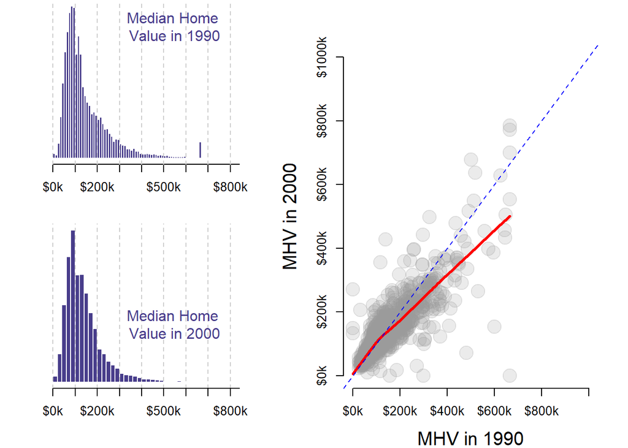

```r
layout.matrix <- matrix( c( 1,3,
                            2,3 ),
                nrow=2, ncol=2, byrow=T )

layout( mat = layout.matrix,
        heights = c(2,2), # Heights of the two rows
        widths =  c(3,4)) # Widths of the two columns

# layout.show(3)

par( mar=c(4,0,0,2) )

hist( mhv.90/1000, breaks=50,
      xlim=c(-200,800), yaxt="n", xaxt="n",
      xlab="", cex.lab=1,
      ylab="", main="",
      col="darkslateblue", border="white" )

axis( side=1, at=seq( from=0, to=1000, by=100 ),
      labels=paste0( "$", seq( from=0, to=1000, by=100 ), "k" ) )

abline( v=seq(0,1000,100), lty=2, col="gray80" )

text( 550, 4000, labels="Median Home \nValue in 1990",
      col="darkslateblue", cex=1.2 )



hist( mhv.00/1000, breaks=50,
      xlim=c(-200,800), yaxt="n", xaxt="n",
      xlab="", cex.lab=1,
      ylab="", main="",
      col="darkslateblue", border="white" )

abline( v=seq(0,1000, 100 ), lty=2, col="gray80" )

text( 550, 3500, labels="Median Home \nValue in 2000",
      col="darkslateblue", cex=1.2 )

axis( side=1, at=seq( from=0, to=1000, by=100 ),
      labels=paste0( "$", seq( from=0, to=1000, by=100 ), "k" ) )


# data reduction - filter 1,000 observations

df <- data.frame( v90=mhv.90/1000, v00=mhv.00/1000 )
df <- sample_n( df, 1000 )

par( mar=c(4,5,3,2) )

jplot( df$v90, df$v00,
       lab1="MHV in 1990", lab2="MHV in 2000",
       xlim=c(0,1000), ylim=c(0,1000),
       axes=F )

abline( a=0, b=1, lty=2, col="blue" )
axis( side=1, at=seq( from=0, to=1000, by=200 ),
      labels=paste0( "$", seq( from=0, to=1000, by=200 ), "k" ) )
axis( side=2, at=seq( from=0, to=1000, by=200 ),
      labels=paste0( "$", seq( from=0, to=1000, by=200 ), "k" ) )
```

### Change in MHV 1990-2000

If a home worth $10 million increased in value by $100k over ten years it would not be that surprising. If a home worth $50k increased by $100k over the same period that is a growth of 200% and is notable.

The change in value variable only reports absolute change, but does not provide a sense of whether that is a big or small amount for the census tract.

The percent change variable provides some context for growth rates of value in census tracts.

```r
# small initial values are skewing percentages
#
# an average home value below $10k is really low -
# these must be mostly vacant lots?

# interpretation is hard if there were no homes in 2000
# and thus an artificially low MHV. i don't trust cases
# that go from homes worth $10k to regular value
# because it is more likely errors in data or noise
# than meaningful variance
#
# quick filter to remove all of the problematic obs
# but need to go back and see which cases are problematic


mhv.90[ mhv.90 < 10000 ] <- NA
pct.change <- mhv.change / mhv.90
summary( pct.change ) %>% pander()
```

| Min. | 1st Qu. | Median | Mean | 3rd Qu. | Max. | NA’s |
| --- | --- | --- | --- | --- | --- | --- |
| -1 | -0.1676 | -0.005433 | 0.03995 | 0.1905 | 28.04 | 145 |

```r
# how many cases had increases above 500%
sum( pct.change > 5, na.rm=T )
```

```
## [1] 26
```

```r
# preview tracts with large increases in home values
# to see if increases make sense

d %>%
  filter( pct.change > 5 ) %>%
  pander()
```

Table continues below

| tractid | mhmval90 | mhmval00 | hinc90 | hu90 | own90 | rent90 |
| --- | --- | --- | --- | --- | --- | --- |
| fips-01-097-000402 | 67489 | 593427 | 4999 | 673 | 15 | 651 |
| fips-04-019-000100 | 73036 | 625000 | 5060 | 457.6 | 22.89 | 382.4 |
| fips-12-099-002600 | 63800 | 625000 | 15820 | 242 | 20 | 188 |
| fips-13-121-002100 | 32500 | 261100 | 4999 | 1080 | 8 | 999 |
| fips-17-031-842200 | 21602 | 281776 | 6861 | 1239 | 9.245 | 738.5 |
| fips-17-167-001400 | 55000 | 1e+06 | 8927 | 678 | 4 | 590 |
| fips-26-163-518000 | 25000 | 314300 | 12325 | 1227 | 31 | 981.9 |
| fips-31-055-001600 | 27500 | 1e+06 | 8130 | 715.3 | 10.99 | 584.5 |
| fips-36-005-011700 | 14499 | 128583 | 11423 | 487 | 30 | 424 |
| fips-36-005-012102 | 17500 | 225000 | 14850 | 467 | 8 | 438 |
| fips-36-005-014300 | 38500 | 350000 | 9234 | 265.8 | 23.53 | 226.6 |
| fips-36-005-023702 | 14999 | 132807 | 11795 | 388 | 6 | 329 |
| fips-36-047-006300 | 43800 | 354000 | 35827 | 869 | 214 | 612 |
| fips-36-047-044100 | 23300 | 206300 | 16183 | 1769 | 209 | 1517 |
| fips-36-061-001800 | 42500 | 667800 | 19707 | 2748 | 65 | 2601 |
| fips-36-061-005502 | 87500 | 992300 | 46957 | 1017 | 305 | 620 |
| fips-36-061-011700 | 101489 | 1e+06 | 5187 | 56 | 0 | 41 |
| fips-40-109-102500 | 52500 | 531300 | 5426 | 518 | 21 | 373 |
| fips-42-003-020300 | 25127 | 215900 | 19350 | 149.5 | 29.81 | 87.13 |
| fips-47-157-000100 | 21500 | 209300 | 20671 | 842 | 103 | 528 |
| fips-49-035-102500 | 36900 | 325000 | 6110 | 400 | 11 | 349 |
| fips-53-033-008200 | 17725 | 190100 | 15960 | 1703 | 90.88 | 1396 |
| fips-53-033-009200 | 17307 | 350000 | 6600 | 1058 | 18.49 | 991.6 |
| fips-53-035-080800 | 67500 | 625000 | 21667 | 702 | 3 | 693 |
| fips-53-063-003500 | 20620 | 798100 | 6129 | 1900 | 15.99 | 1662 |
| fips-55-079-014100 | 37500 | 450000 | 6089 | 631 | 9 | 587 |

Table continues below

| empclf90 | clf90 | unemp90 | prof90 | dpov90 | npov90 | ag25up90 | hs90 |
| --- | --- | --- | --- | --- | --- | --- | --- |
| 293 | 535 | 242 | 14 | 2139 | 1857 | 812 | 665 |
| 162.6 | 181.9 | 19.31 | 40.21 | 581.4 | 358.8 | 498.3 | 312.9 |
| 448 | 448 | 0 | 62 | 575 | 120 | 527 | 421 |
| 550 | 732 | 182 | 27 | 2663 | 1862 | 1426 | 1164 |
| 261.5 | 502.3 | 240.8 | 41.13 | 2430 | 1946 | 1066 | 953.5 |
| 294 | 328 | 34 | 126 | 692 | 247 | 710 | 408 |
| 673.9 | 840.9 | 167 | 313 | 1743 | 728.9 | 1326 | 700.9 |
| 1164 | 1206 | 41.96 | 242.8 | 855.2 | 448.6 | 631.4 | 282.7 |
| 395 | 511 | 116 | 67 | 1339 | 523 | 688 | 525 |
| 342 | 463 | 121 | 20 | 1292 | 699 | 618 | 557 |
| 156.9 | 203.9 | 47.06 | 34.86 | 698.1 | 321.6 | 377.4 | 309.4 |
| 295 | 353 | 58 | 8 | 1268 | 623 | 591 | 498 |
| 1001 | 1039 | 38 | 398 | 1736 | 187 | 1376 | 628 |
| 1907 | 2183 | 276 | 169 | 5174 | 2082 | 2942 | 2329 |
| 4449 | 4783 | 334 | 522 | 9247 | 2319 | 5872 | 4722 |
| 1358 | 1581 | 223 | 925 | 2138 | 433 | 1730 | 403 |
| 18 | 27 | 9 | 10 | 232 | 197 | 104 | 94 |
| 212 | 255 | 43 | 76 | 630 | 352 | 596 | 419 |
| 106 | 116 | 10 | 20.75 | 287.2 | 50.85 | 206.3 | 156.9 |
| 544 | 578 | 34 | 177 | 1209 | 537 | 854 | 482 |
| 409 | 482 | 73 | 45 | 888 | 502 | 805 | 570 |
| 896.4 | 999.3 | 102.9 | 203.5 | 1877 | 368.2 | 1636 | 594.7 |
| 713.2 | 886.9 | 173.8 | 134.8 | 1789 | 962.1 | 1631 | 1115 |
| 543 | 593 | 50 | 59 | 3003 | 450 | 1176 | 529 |
| 447.7 | 585.7 | 137.9 | 101.9 | 2149 | 1114 | 1963 | 1257 |
| 268 | 444 | 176 | 36 | 1906 | 1557 | 739 | 624 |

Table continues below

| col90 | pop90.x | nhwht90 | nhblk90 | hisp90 | asian90 | cbsa |
| --- | --- | --- | --- | --- | --- | --- |
| 7.002 | 2103 | 2 | 2098 | 2 | 1 | 33660 |
| 53.07 | 551.8 | 328.4 | 34.92 | 171.4 | 3.274 | 46060 |
| 0 | 550 | 210 | 290 | 46 | 0 | 48424 |
| 80 | 2706 | 320 | 2273 | 19 | 87 | 12060 |
| 36.29 | 2277 | 42.62 | 2195 | 33.88 | 0 | 16974 |
| 140 | 911 | 770 | 123 | 10 | 6 | 44100 |
| 311 | 1844 | 416.9 | 1342 | 26 | 48.99 | 19804 |
| 225.8 | 2410 | 1989 | 191.8 | 102.9 | 114.9 | 36540 |
| 24 | 1360 | 9 | 424 | 914 | 0 | 35644 |
| 8 | 1309 | 10 | 120 | 1175 | 0 | 35644 |
| 22.66 | 797.4 | 16.56 | 427.9 | 346 | 0 | 35644 |
| 0 | 1340 | 66 | 181 | 1028 | 52 | 35644 |
| 561 | 1699 | 1431 | 15 | 225 | 27 | 35644 |
| 194 | 5280 | 772 | 108 | 3489 | 826 | 35644 |
| 500 | 9247 | 860 | 187 | 1882 | 6289 | 35644 |
| 1067 | 2112 | 1614 | 169 | 224 | 99 | 35644 |
| 0 | 252 | 41 | 72 | 136 | 3 | 35644 |
| 84 | 647 | 449 | 96 | 47 | 7 | 36420 |
| 41.34 | 272.8 | 79.78 | 179.2 | 7.923 | 3.923 | 38300 |
| 259 | 1278 | 423 | 831 | 3 | 14 | 32820 |
| 70 | 937 | 646 | 48 | 151 | 46 | 41620 |
| 478.3 | 1938 | 1494 | 135.9 | 69.21 | 188.2 | 42644 |
| 176.6 | 1800 | 862.3 | 309.7 | 139.3 | 437.3 | 42644 |
| 103 | 3086 | 2254 | 279 | 241 | 285 | 14740 |
| 244.8 | 2150 | 1849 | 94.95 | 61.98 | 28.98 | 44060 |
| 0 | 1816 | 43 | 1676 | 78 | 14 | 33340 |

Table continues below

| cbsaname | p.white | p.black | p.hisp | p.asian | p.hs |
| --- | --- | --- | --- | --- | --- |
| Mobile, AL | 0.0951 | 99.76 | 0.09511 | 0.04755 | 82.76 |
| Tucson, AZ | 59.51 | 6.328 | 31.06 | 0.5933 | 73.45 |
| West Palm Beach-Boca Raton-Boynton FL | 38.18 | 52.73 | 8.364 | 0 | 79.89 |
| Atlanta-Sandy Springs-Marietta, GA | 11.83 | 84 | 0.7021 | 3.215 | 87.24 |
| Chicago-Naperville-Joliet, IL | 1.872 | 96.39 | 1.488 | 0 | 92.89 |
| Springfield, IL | 84.52 | 13.5 | 1.098 | 0.6586 | 77.18 |
| Detroit-Livonia-Dearborn, MI | 22.61 | 72.78 | 1.41 | 2.657 | 76.32 |
| Omaha-Council Bluffs, NE-IA | 82.55 | 7.96 | 4.27 | 4.768 | 80.54 |
| New York-Wayne-White Plains, NY-NJ | 0.6618 | 31.18 | 67.21 | 0 | 79.8 |
| New York-Wayne-White Plains, NY-NJ | 0.7639 | 9.167 | 89.76 | 0 | 91.42 |
| New York-Wayne-White Plains, NY-NJ | 2.077 | 53.66 | 43.39 | 0 | 87.99 |
| New York-Wayne-White Plains, NY-NJ | 4.925 | 13.51 | 76.72 | 3.881 | 84.26 |
| New York-Wayne-White Plains, NY-NJ | 84.23 | 0.8829 | 13.24 | 1.589 | 86.41 |
| New York-Wayne-White Plains, NY-NJ | 14.62 | 2.045 | 66.08 | 15.64 | 85.76 |
| New York-Wayne-White Plains, NY-NJ | 9.3 | 2.022 | 20.35 | 68.01 | 88.93 |
| New York-Wayne-White Plains, NY-NJ | 76.42 | 8.002 | 10.61 | 4.688 | 84.97 |
| New York-Wayne-White Plains, NY-NJ | 16.27 | 28.57 | 53.97 | 1.19 | 90.38 |
| Oklahoma City, OK | 69.4 | 14.84 | 7.264 | 1.082 | 84.4 |
| Pittsburgh, PA | 29.24 | 65.68 | 2.904 | 1.438 | 96.12 |
| Memphis, TN-MS-AR | 33.1 | 65.02 | 0.2347 | 1.095 | 86.77 |
| Salt Lake City, UT | 68.94 | 5.123 | 16.12 | 4.909 | 79.5 |
| Seattle-Bellevue-Everett, WA | 77.09 | 7.011 | 3.571 | 9.707 | 65.61 |
| Seattle-Bellevue-Everett, WA | 47.9 | 17.2 | 7.74 | 24.29 | 79.16 |
| Bremerton-Silverdale, WA | 73.04 | 9.041 | 7.809 | 9.235 | 53.74 |
| Spokane, WA | 86 | 4.417 | 2.883 | 1.348 | 76.53 |
| Milwaukee-Waukesha-West Allis, WI | 2.368 | 92.29 | 4.295 | 0.7709 | 84.44 |

| p.col | p.prof | p.unemp | pov.rate |
| --- | --- | --- | --- |
| 0.8622 | 4.778 | 45.23 | 86.82 |
| 10.65 | 24.73 | 10.61 | 61.7 |
| 0 | 13.84 | 0 | 20.87 |
| 5.61 | 4.909 | 24.86 | 69.92 |
| 3.406 | 15.73 | 47.94 | 80.06 |
| 19.72 | 42.86 | 10.37 | 35.69 |
| 23.45 | 46.44 | 19.86 | 41.82 |
| 35.76 | 20.86 | 3.48 | 52.45 |
| 3.488 | 16.96 | 22.7 | 39.06 |
| 1.294 | 5.848 | 26.13 | 54.1 |
| 6.005 | 22.22 | 23.08 | 46.07 |
| 0 | 2.712 | 16.43 | 49.13 |
| 40.77 | 39.76 | 3.657 | 10.77 |
| 6.594 | 8.862 | 12.64 | 40.24 |
| 8.515 | 11.73 | 6.983 | 25.08 |
| 61.68 | 68.11 | 14.1 | 20.25 |
| 0 | 55.56 | 33.33 | 84.91 |
| 14.09 | 35.85 | 16.86 | 55.87 |
| 20.04 | 19.58 | 8.621 | 17.7 |
| 30.33 | 32.54 | 5.882 | 44.42 |
| 8.696 | 11 | 15.15 | 56.53 |
| 29.24 | 22.7 | 10.3 | 19.61 |
| 10.82 | 18.9 | 19.59 | 53.77 |
| 8.759 | 10.87 | 8.432 | 14.99 |
| 12.47 | 22.76 | 23.55 | 51.86 |
| 0 | 13.43 | 39.64 | 81.69 |

Plot the percent change variable:

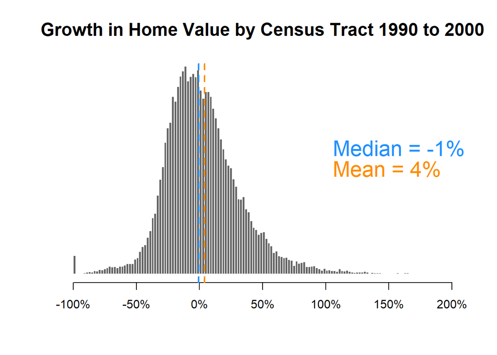

```r
hg <-
hist( pct.change, breaks=2000,
      xlim=c(-1,2), yaxt="n", xaxt="n",
      xlab="", cex.main=1.5,
      ylab="", main="Growth in Home Value by Census Tract 1990 to 2000",
      col="gray40", border="white" )

axis( side=1, at=seq( from=-1, to=2, by=0.5 ),
      labels=paste0( seq( from=-100, to=200, by=50 ), "%" ) )

ymax <- max( hg$count )

mean.x <- mean( pct.change, na.rm=T )
abline( v=mean.x, col="darkorange", lwd=2, lty=2 )
text( x=1, y=(0.5*ymax),
      labels=paste0( "Mean = ", round(100*mean.x,0), "%"),
      col="darkorange", cex=1.8, pos=4 )

median.x <- median( pct.change, na.rm=T )
abline( v=median.x, col="dodgerblue", lwd=2, lty=2 )
text( x=1, y=(0.6*ymax),
      labels=paste0( "Median = ", round(100*median.x,0), "%"),
      col="dodgerblue", cex=1.8, pos=4 )
```

### Group Growth Rates By Metro Area

We often want to disagregate descriptives by some grouping in the data, such as metro areas.

dplyr makes this easy by grouping then summarizing the data.

```r
d$mhv.change <- mhv.change
d$pct.change <- pct.change[na.rm = TRUE]
d$mhv.90 <- mhv.90
d$mhv.00 <- mhv.00

d %>%
  group_by( cbsaname ) %>%
  summarize( ave.change = median( mhv.change, na.rm=T ),
             ave.change.d = dollar( round(ave.change,0) ),
             growth = 100 * median( pct.change, na.rm=T ) ) %>%
  ungroup() %>%
  arrange( - growth ) %>%
  select( - ave.change ) %>%
  head( 25 ) %>%
  pander()
```

| cbsaname | ave.change.d | growth |
| --- | --- | --- |
| Corvallis, OR | $72,594 | 73.71 |
| Portland-Vancouver-Beaverton, OR-WA | $67,180 | 70.12 |
| Salt Lake City, UT | $59,924 | 67.38 |
| Boulder, CO | $92,987 | 66.91 |
| Provo-Orem, UT | $59,081 | 66.2 |
| Salem, OR | $48,018 | 59.7 |
| Eugene-Springfield, OR | $50,238 | 59.54 |
| Fort Collins-Loveland, CO | $56,292 | 54.78 |
| Longview, WA | $39,921 | 53.55 |
| Missoula, MT | $44,774 | 52.85 |
| Jackson, MI | $27,679 | 51.92 |
| Greeley, CO | $40,425 | 50.21 |
| Wenatchee, WA | $44,681 | 48.98 |
| Detroit-Livonia-Dearborn, MI | $28,082 | 47.92 |
| Yakima, WA | $30,346 | 47.88 |
| Ogden-Clearfield, UT | $41,282 | 47.06 |
| Denver-Aurora, CO | $50,896 | 46.49 |
| Monroe, MI | $41,015 | 45.94 |
| Bay City, MI | $26,081 | 45.6 |
| Logan, UT-ID | $34,737 | 45 |
| Eau Claire, WI | $27,247 | 41.62 |
| Madison, WI | $42,128 | 40.75 |
| Sioux Falls, SD | $30,340 | 39.73 |
| Grand Junction, CO | $33,811 | 39.52 |
| Mount Vernon-Anacortes, WA a | $41,121 | 39.23 |

### Comparison

How do changes in home value differ between the 1990-2000 period and 2000-2010?

# Part 02 - Measuring Gentrification

The original merged dataset we saved as d.full so we don’t need to reload it:

```r
d.full$mhv.90 <- mhv.90
d.full$mhv.00 <- mhv.00
d.full$mhv.change <- mhv.change
d.full$pct.change <- pct.change
```

### Select Gentrification Variables

Select variables for operationalizing a definition of gentrification:

We need to add some variables from 2000:

Recall we created a 1990 to 2000 variable list for reference:

```r
head(vars) %>% pander()
```

| type | variables |
| --- | --- |
| shared | a15asn |
| shared | a15blk |
| shared | a15hsp |
| shared | a15ntv |
| shared | a15wht |
| shared | a18und |

```r
d3 <- select( d.full,

             tractid, cbsa, cbsaname,            # ids / units of analysis

             mhv.90, mhv.00, mhv.change, pct.change,    # home value

             hinc90, hu90, own90, rent90,        # ses
             hinc00, hu00, own00, rent00,

             empclf90, clf90, unemp90, prof90,   # employment
             empclf00, clf00, unemp00, prof00,

             dpov90, npov90,                     # poverty
             dpov00, npov00,

             ag25up90, hs90, col90,              # education
             ag25up00, hs00, col00,

             pop90.x, nhwht90, nhblk90, hisp90, asian90,   # race
             pop00.x, nhwht00, nhblk00, hisp00, asian00

          ) # end select


d3 <-
  d3 %>%
  mutate(
          # 1990 variables
          p.white.90 = 100 * nhwht90 / pop90.x,
          p.black.90 = 100 * nhblk90 / pop90.x,
          p.hisp.90 = 100 * hisp90 / pop90.x,
          p.asian.90 = 100 * asian90 / pop90.x,
          p.hs.edu.90 = 100 * (hs90+col90) / ag25up90,
          p.col.edu.90 = 100 * col90 / ag25up90,
          p.prof.90 = 100 * prof90 / empclf90,
          p.unemp.90 = 100 * unemp90 / clf90,
          pov.rate.90 = 100 * npov90 / dpov90,

          # 2000 variables
          p.white.00 = 100 * nhwht00 / pop00.x,
          p.black.00 = 100 * nhblk00 / pop00.x,
          p.hisp.00 = 100 * hisp00 / pop00.x,
          p.asian.00 = 100 * asian00 / pop00.x,
          p.hs.edu.00 = 100 * (hs00+col00) / ag25up00,
          p.col.edu.00 = 100 * col00 / ag25up00,
          p.prof.00 = 100 * prof00 / empclf00,
          p.unemp.00 = 100 * unemp00 / clf00,
          pov.rate.00 = 100 * npov00 / dpov00 )
d3 <-
  d3 %>%
  group_by( cbsaname ) %>%
  mutate( metro.mhv.pct.90 = ntile( mhv.90, 100 ),
          metro.mhv.pct.00 = ntile( mhv.00, 100 ),
          metro.median.pay.90 = median( hinc90, na.rm=T ),
          metro.median.pay.00 = median( hinc00, na.rm=T ),
          metro.race.rank.90 = ntile( (100-p.white.90), 100 ) ) %>%
  ungroup() %>%
  mutate( metro.mhv.pct.change = metro.mhv.pct.00 - metro.mhv.pct.90,
          pay.change = metro.median.pay.00 - metro.median.pay.90,
          race.change = p.white.00 - p.white.90,
          mhv.change = mhv.00 - mhv.90 )
```

Descriptive Statistics of Change Variables

```r
d3 <-
  d3 %>%
  select( c( "tractid", "cbsa", "cbsaname",
             "mhv.90", "mhv.00", "mhv.change","pct.change",
          "p.white.90", "p.black.90", "p.hisp.90", "p.asian.90",
          "p.hs.edu.90", "p.col.edu.90", "p.prof.90",  "p.unemp.90",
          "pov.rate.90", "p.white.00", "p.black.00", "p.hisp.00",
          "p.asian.00", "p.hs.edu.00", "p.col.edu.00", "p.prof.00",
          "p.unemp.00", "pov.rate.00", "metro.mhv.pct.90",
          "metro.mhv.pct.00", "metro.median.pay.90", "metro.median.pay.00",
          "metro.mhv.pct.change", "pay.change", "race.change",
          "metro.race.rank.90") )

head( d3 ) %>% pander()
```

Table continues below

| tractid | cbsa | cbsaname | mhv.90 | mhv.00 | mhv.change |
| --- | --- | --- | --- | --- | --- |
| fips-01-001-020100 | 33860 | Montgomery, AL | 82913 | 76600 | -6313 |
| fips-01-001-020200 | 33860 | Montgomery, AL | 58119 | 72900 | 14781 |
| fips-01-001-020300 | 33860 | Montgomery, AL | 73582 | 79900 | 6318 |
| fips-01-001-020400 | 33860 | Montgomery, AL | 89711 | 89800 | 89.1 |
| fips-01-001-020500 | 33860 | Montgomery, AL | 99419 | 116594 | 17174 |
| fips-01-001-020600 | 33860 | Montgomery, AL | 75714 | 70400 | -5314 |

Table continues below

| pct.change | p.white.90 | p.black.90 | p.hisp.90 | p.asian.90 | p.hs.edu.90 |
| --- | --- | --- | --- | --- | --- |
| -0.07614 | 95.83 | 2.087 | 1.354 | 0.5076 | 80.27 |
| 0.2543 | 36.78 | 62.04 | 0.2954 | 0.5416 | 84.53 |
| 0.08587 | 85.4 | 13.72 | 0.271 | 0.542 | 74.43 |
| 0.0009932 | 97.61 | 0.818 | 0.5453 | 0.6589 | 67.55 |
| 0.1727 | 93.74 | 4.068 | 1.235 | 0.8249 | 61.82 |
| -0.07019 | 77.37 | 21.37 | 0.848 | 0.2047 | 77.15 |

Table continues below

| p.col.edu.90 | p.prof.90 | p.unemp.90 | pov.rate.90 | p.white.00 | p.black.00 |
| --- | --- | --- | --- | --- | --- |
| 20 | 24.91 | 3.468 | 9.887 | 89.69 | 7.548 |
| 12.83 | 18 | 9.011 | 19.83 | 35.47 | 62.21 |
| 14.09 | 19.19 | 6.336 | 11.4 | 82 | 14.91 |
| 22.01 | 28.79 | 4.496 | 6.79 | 93.79 | 2.59 |
| 29.88 | 29.66 | 3.07 | 5.536 | 89.64 | 6.07 |
| 10.22 | 19.59 | 7.438 | 17.81 | 79.93 | 16.9 |

Table continues below

| p.hisp.00 | p.asian.00 | p.hs.edu.00 | p.col.edu.00 | p.prof.00 | p.unemp.00 |
| --- | --- | --- | --- | --- | --- |
| 0.6247 | 0.4164 | 67.4 | 15.65 | 26.76 | 5.275 |
| 0.8457 | 0.6342 | 78.65 | 14.69 | 21.33 | 9.975 |
| 1.647 | 0.8086 | 68.92 | 22.44 | 30.98 | 2.885 |
| 2.217 | 0.878 | 71.13 | 23.05 | 31.84 | 3.514 |
| 1.573 | 1.867 | 65.29 | 32.07 | 40.38 | 1.67 |
| 1.954 | 0.3256 | 75.7 | 16.07 | 24.34 | 5.505 |

Table continues below

| pov.rate.00 | metro.mhv.pct.90 | metro.mhv.pct.00 | metro.median.pay.90 |
| --- | --- | --- | --- |
| 12.68 | 56 | 44 | 27374 |
| 22.71 | 28 | 37 | 27374 |
| 7.664 | 46 | 48 | 27374 |
| 4.548 | 64 | 60 | 27374 |
| 3.692 | 70 | 74 | 27374 |
| 15.22 | 49 | 34 | 27374 |

Table continues below

| metro.median.pay.00 | metro.mhv.pct.change | pay.change | race.change |
| --- | --- | --- | --- |
| 36972 | -12 | 9598 | -6.133 |
| 36972 | 9 | 9598 | -1.315 |
| 36972 | 2 | 9598 | -3.399 |
| 36972 | -4 | 9598 | -3.826 |
| 36972 | 4 | 9598 | -4.1 |
| 36972 | -15 | 9598 | 2.561 |

| metro.race.rank.90 |
| --- |
| 5 |
| 72 |
| 28 |
| 1 |
| 12 |
| 46 |

```r
d3 <- data.frame(d3)
stargazer( d3,
           type=s.type,
           digits=0,
           summary.stat = c("min", "p25","median","mean","p75","max") )
```

| Statistic | Min | Pctl(25) | Median | Mean | Pctl(75) | Max |
| --- | --- | --- | --- | --- | --- | --- |
| mhv.90 | 11,827 | 78,647 | 115,438 | 150,192 | 189,286 | 666,501 |
| mhv.00 | 0 | 81,600 | 119,900 | 144,738 | 173,894 | 1,000,001 |
| mhv.change | -666,501 | -25,072 | -554 | -5,586 | 17,977 | 963,343 |
| pct.change | -1 | -0 | -0 | 0 | 0 | 28 |
| p.white.90 | 0 | 64 | 87 | 74 | 95 | 100 |
| p.black.90 | 0 | 1 | 3 | 12 | 10 | 100 |
| p.hisp.90 | 0 | 1 | 3 | 10 | 9 | 100 |
| p.asian.90 | 0 | 0 | 1 | 3 | 3 | 94 |
| p.hs.edu.90 | 0 | 69 | 74 | 74 | 80 | 100 |
| p.col.edu.90 | 0 | 10 | 18 | 22 | 30 | 100 |
| p.prof.90 | 0 | 17 | 25 | 27 | 34 | 100 |
| p.unemp.90 | 0 | 4 | 5 | 7 | 8 | 64 |
| pov.rate.90 | 0 | 4 | 8 | 12 | 16 | 100 |
| p.white.00 | 0 | 47 | 78 | 67 | 91 | 100 |
| p.black.00 | 0 | 1 | 4 | 14 | 14 | 100 |
| p.hisp.00 | 0 | 2 | 4 | 13 | 15 | 100 |
| p.asian.00 | 0 | 1 | 2 | 5 | 5 | 95 |
| p.hs.edu.00 | 0 | 67 | 72 | 72 | 77 | 100 |
| p.col.edu.00 | 0 | 12 | 21 | 26 | 36 | 100 |
| p.prof.00 | 0 | 23 | 31 | 34 | 43 | 100 |
| p.unemp.00 | 0 | 3 | 5 | 6 | 8 | 100 |
| pov.rate.00 | 0 | 4 | 9 | 12 | 17 | 100 |
| metro.mhv.pct.90 | 1 | 20 | 41 | 45 | 68 | 100 |
| metro.mhv.pct.00 | 1 | 20 | 41 | 45 | 68 | 100 |
| metro.median.pay.90 | 14,871 | 28,906 | 32,457 | 32,924 | 35,833 | 52,374 |
| metro.median.pay.00 | 23,012 | 39,457 | 43,139 | 45,054 | 49,522 | 73,701 |
| metro.mhv.pct.change | -99 | -5 | 0 | 0 | 6 | 99 |
| pay.change | 4,930 | 9,775 | 11,441 | 12,130 | 14,001 | 26,211 |
| race.change | -100 | -12 | -5 | -8 | -2 | 100 |
| metro.race.rank.90 | 1 | 20 | 41 | 45 | 68 | 100 |

### Operationalizing Gentrification

Which definition did you select for gentrification, and how would you operationalize it?

```r
# income
# percent white
# home values absolute
# home value relative to metro
# education stats ?
# employment stats ?
# income stats ?
# growth of pop per tract (density) ?


# home value in lower than average home in a metro in 1990
poor.1990 <- d3$metro.mhv.pct.90 < 50

# above average diversity for metro
diverse.1990 <- d3$metro.race.rank.90 > 50

# home values increased more than overall city gains
# change in percentile rank within the metro
mhv.pct.increase <- d3$metro.mhv.pct.change > 0

# faster than average growth
# 25% growth in value is median for the country
home.val.rise <- d3$pct.change > 25

# proportion of whites increases by more than 3 percent
# measured by increase in white
loss.diversity <- d3$race.change > 3

g.flag <- poor.1990 & diverse.1990 & mhv.pct.increase & home.val.rise & loss.diversity

num.candidates <-  sum( poor.1990 & diverse.1990, na.rm=T )
num.gentrified <- sum( g.flag, na.rm=T )

num.gentrified
```

```
## [1] 0
```

```r
num.candidates
```

```
## [1] 17560
```

```r
num.gentrified / num.candidates
```

```
## [1] 0
```

This might skew numbers?

```r
# small initial values are skewing percentages
#
# an average home value below $10k is really low -
# these must be mostly vacant lots?

mhv.90[ mhv.90 < 1000 ] <- NA
pct.change <- 100 * ( mhv.change / mhv.90 )
summary( pct.change ) %>% pander()
```

| Min. | 1st Qu. | Median | Mean | 3rd Qu. | Max. | NA’s |
| --- | --- | --- | --- | --- | --- | --- |
| -100 | -16.76 | -0.5433 | 3.995 | 19.05 | 2804 | 145 |

### Discussion

What do you think? Is that the right way to operationalize it? Do you care about relative diversity (more diverse neighborhood than rest of the city) or absolute (percentage of non-whites regardless of city diversity).

*I do think relative diversity is important; a neighborhood in areas with a higher percentage of whites might be considered more diverse at 10% than a more diverse neighborhood would be at 50%. In other words, if an area has 70% non-whites, a neighborhood with 10% non-whites is a big difference from a neighborhood with 10% non-whites in an area with 30% non-whites.*

Do we care about absolute increase in value, or relative to the national average? The national average would include all of the gentrifying tracts, which could skew it upward and thus make it a poor benchmark? Maybe look at the average increase in value for non-gentrification candadidates?

*I agree that the national average would skew the data for the same reason relative diversity is imporant; home values differ drastically from one area to another - even within the same state.*

*In order to define gentrification, I believe changes in both home value and diversity need to be looked at from a relative perspective. How much did home values change compared to surrounding tracts? How did diversity change compared to surrounding tracts? Comparing it to nearby tracts (maybe within the same county) would give the most accurate description of the relative change and thus gentrification.*

# Part 03 - Spatial Patterns

Histograms and scatterplots help us understand the statistical properties and relationships between variables in our dataset. Due to the nature of cities, these relationships are all shaped by their location in the city. Geography matters a great deal in urban policy, so it should not be ignored.

Simple simple choropleth maps can be extremely helpful in understanding relationships in the data.

Revisit one of the labs from CPP 529 and prepare a Dorling Cartogram shapefile for your project. You can select one or more cities of your choice (you can use the same city if you like).

Follow the instructions for saving your cartogram as a GeoJSON file. These files are nice because they can be stored on GitHub and read directly into R. If you create it right the first time you can use it over and over after that.

```r
library( geojsonio )   # read shapefiles
library( sp )          # work with shapefiles
library( sf )          # work with shapefiles - simple features format
library( mclust )      # cluster analysis
```

```r
library( tmap )        # theme maps
library( ggplot2 )     # graphing
library( ggthemes )    # nice formats for ggplots
library( dplyr )       # data wrangling
library( pander )      # formatting RMD tables
library( tidycensus )
library( cartogram )  # spatial maps w/ tract size bias reduction
library( maptools )   # spatial object manipulation
library( colorspace )
```

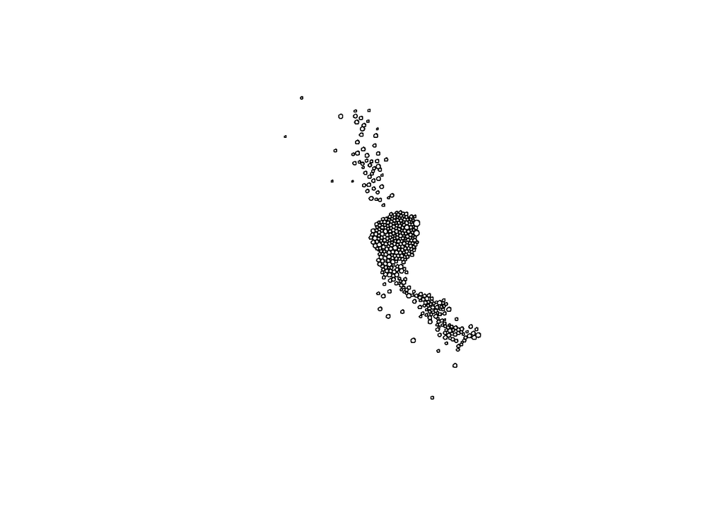

```r
# load dorling cartogram

dorling.file <- "https://aprilpeck.github.io/sf_dorling.geojson"
sf.ca <- geojson_read( x=dorling.file,  what="sp" )
plot( sf.ca )
```

*I did the following steps to merge the data before creating my geojson*

```r
#grep( "^SAN FRAN", crosswalk$msaname, value=TRUE )
#these.sf <- crosswalk$msaname == "SAN FRANCISCO, CA"   # Find San Francisco (T/F)
#these.fips <- crosswalk$fipscounty[ these.sanfran ]         # Find SF counties
#these.fips <- na.omit( these.fips )

#state.fips <- substr( these.fips, 1, 2 )                    # Substring state code
#county.fips <- substr( these.fips, 3, 5 )                   # substring county codes

#sf.pop <-
#  get_acs( geography = "tract", variables = "B01003_001",
#           state = "06", county = county.fips[state.fips=="06"], geometry = TRUE ) %>%
#  select( GEOID, estimate ) %>%
#  rename( POP=estimate )

# convert tractid to geoid
#d.full$geoid <- gsub( "-", "", d.full$tractid)    # remove dashes
#d.full$geoid <- substr( d.full$geoid, 5, 16 )


# merge with census data
#sf <- merge(sf.pop, d.full, by.x = "GEOID", by.y = "geoid")
```

Please create the following choropleth maps and report your main findings:

### Home Values

Describe the distribution of home values in 1990 - where are high and low-value tracts located in the city/cities?

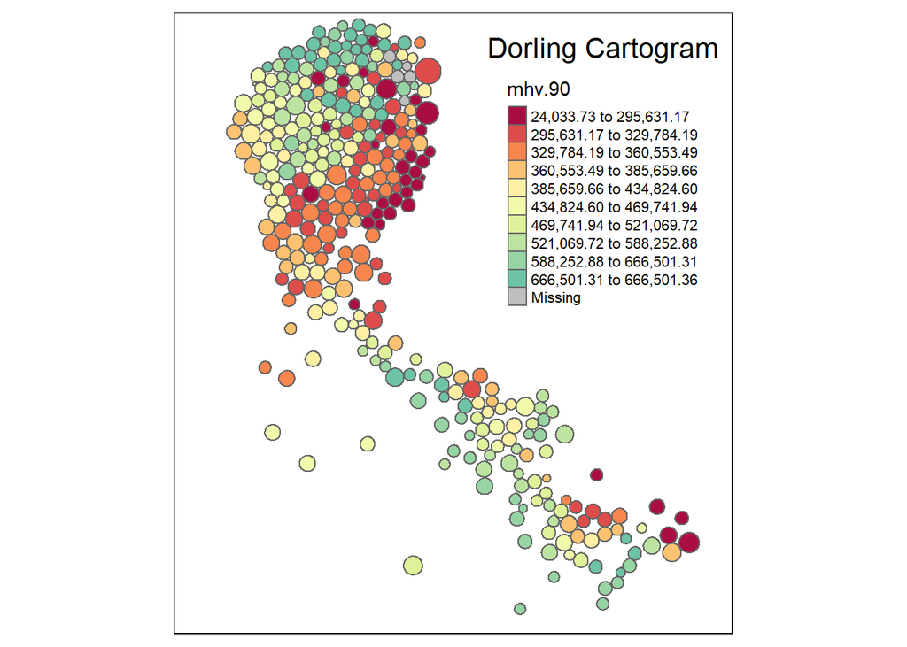

```r
sf.ca <- spTransform( sf.ca, CRS("+init=epsg:3395") )

bb <- st_bbox( c( xmin =  -13645063, xmax = -13592179,
                  ymin = 4470284, ymax = 4529237  ),
               crs = st_crs("+init=epsg:3395"))
tm_shape( sf.ca, bbox=bb ) +
  tm_polygons( col="mhv.90", n=10, style="quantile", palette="Spectral" ) +
  tm_layout( "Dorling Cartogram", title.position=c("right","top") )
```

*As can be anticipated with most cities at this time, the inner city tracts had the lowest values and the farther from the city center the tract is, the higher the median value (with a few exceptions).*

Compare values in 2000 to changes in values from 1990-2000. Do the largest gains occur in tracts with above or below-average home prices in 2000?

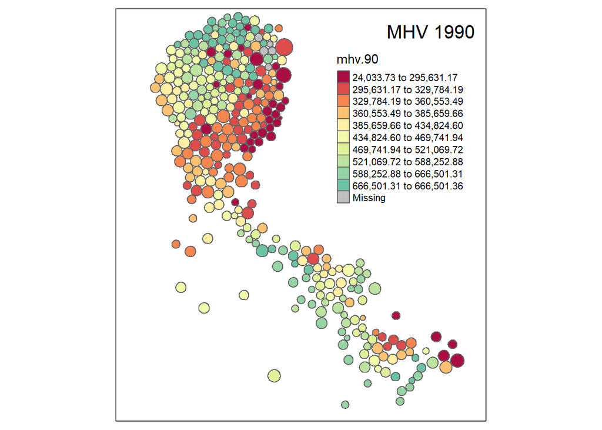

```r
tm_shape( sf.ca, bbox=bb ) +
  tm_polygons( col="mhv.90", n=10, style="quantile", palette="Spectral" ) +
  tm_layout( "MHV 1990", title.position=c("right","top") )
```

```r
tm_shape( sf.ca, bbox=bb ) +
  tm_polygons( col="mhv.change", n=10, style="quantile", palette="Spectral" ) +
  tm_layout( "MHV Change", title.position=c("right","top") )
```

```
## Variable(s) "mhv.change" contains positive and negative values, so midpoint is set to 0. Set midpoint = NA to show the full spectrum of the color palette.
```

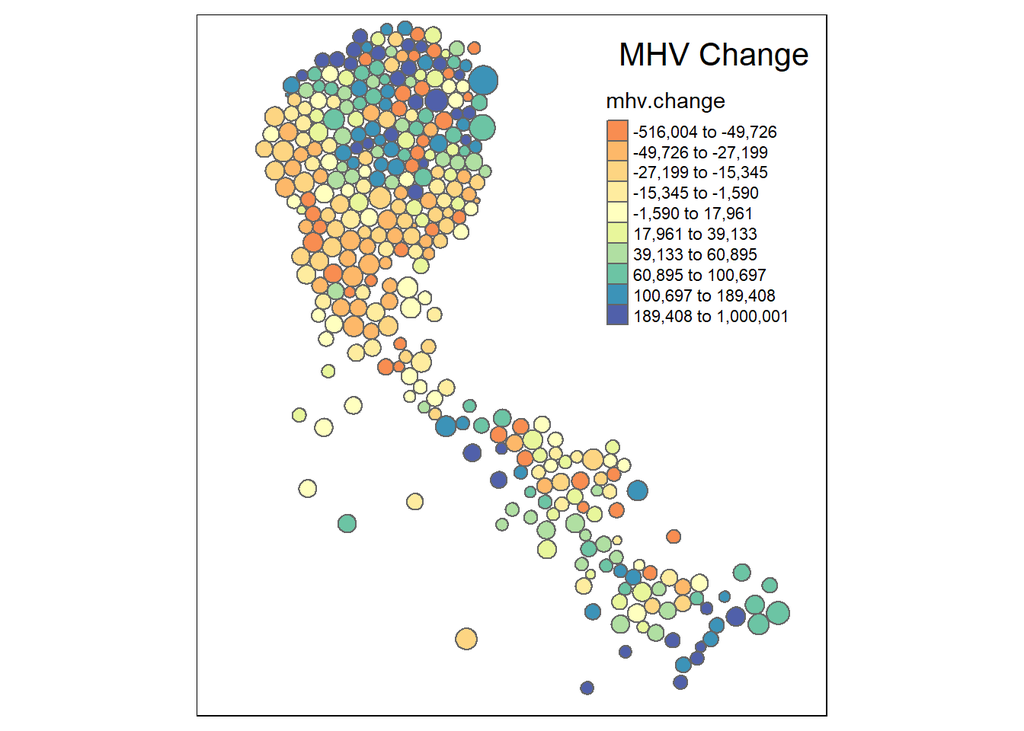

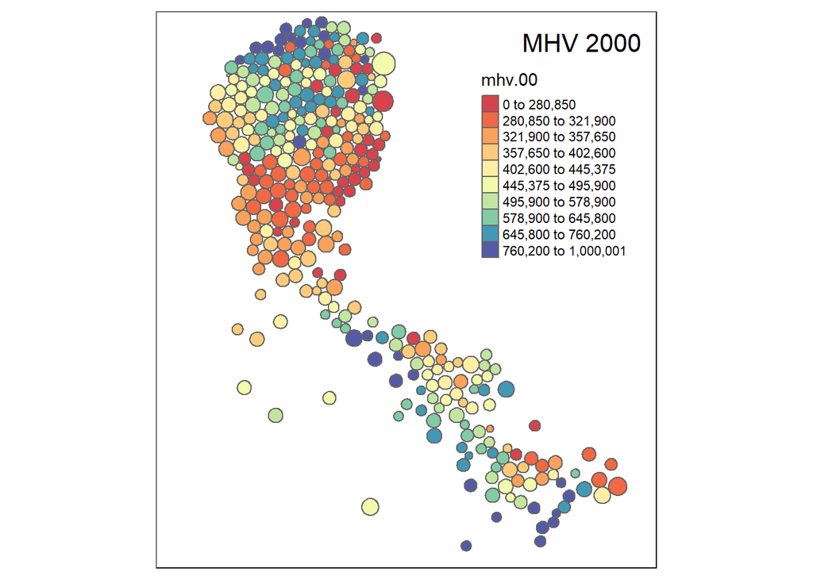

```r
tm_shape( sf.ca, bbox=bb ) +
  tm_polygons( col="mhv.00", n=10, style="quantile", palette="Spectral" ) +
  tm_layout( "MHV 2000", title.position=c("right","top") )
```

```r
tm_shape( sf.ca, bbox=bb ) +
  tm_polygons( col="pct.change", n=10, style="quantile", palette="Spectral" ) +
  tm_layout( "Dorling Cartogram", title.position=c("right","top") )
```

```
## Variable(s) "pct.change" contains positive and negative values, so midpoint is set to 0. Set midpoint = NA to show the full spectrum of the color palette.
```

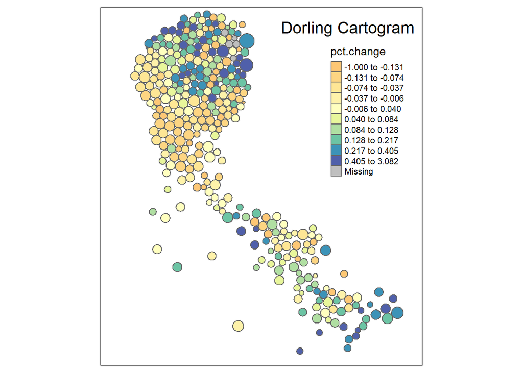

*The largest changes occur in tracts with above-average home prices in 1990. Tracts with below-average prices continued to drop while those with higher prices increased.*

### Gentrification

Create a map that highlights tracts that are candidates for gentrification in 2000 and tracts that gentrify between 1990 and 2000. Do you find any meaningful patterns in where gentrification occurs?

*To be honest, I don’t even know where to start on this. I’m not sure how to find tracts that gentrified or are candidates for gentrification and will most likely schedule an meeting with you to discuss.*